# Final Notebook After Strict Cleaning

```python
import pandas as pd
import numpy  as np
import matplotlib.pyplot as plt
import seaborn as sns
%matplotlib inline
```

```python
df = pd.read_excel (r'Household Socio Economic Data.xlsx')
```

verifying no duplicate rows

```python
df.HouseholdId.duplicated()
```

```
0        False
1        False
2        False
3        False
4        False
         ...
11629    False
11630    False
11631    False
11632    False
11633    False
Name: HouseholdId, Length: 11634, dtype: bool
```

dropping first column with too many nulls

```python
df.drop('NotEat', axis = 1, inplace = True)
```

```python
df.head()
```

|  | HouseholdId | ObseravtionDate | WaterSource | Toilet | ConnectedToGrid | CookingFuel | WallMaterial | FloorMaterial | Bedrooms | Crime | FinancialStatus | CutMeals | CutMealsFrequency | NotEatFrequency | ChildMealSkipCut | ChildMealSkipCutFrequency |
| --- | --- | --- | --- | --- | --- | --- | --- | --- | --- | --- | --- | --- | --- | --- | --- | --- |
| 0 | 111000 | 2017-10-26 | 2 | 2 | 1.0 | 4 | 3 | 2 | 2.0 | 0 | 0 | 0.0 | 0 | 0 | NaN | 0 |
| 1 | 111001 | 2017-10-24 | 2 | 2 | 1.0 | 4 | 1 | 2 | 4.0 | 0 | 0 | 0.0 | 0 | 0 | NaN | 0 |
| 2 | 111002 | 2017-10-26 | 2 | 2 | 1.0 | 4 | 1 | 2 | 3.0 | 0 | 0 | 0.0 | 0 | 0 | NaN | 0 |
| 3 | 111003 | 2017-10-26 | 2 | 2 | 1.0 | 4 | 1 | 2 | 5.0 | 0 | 0 | 0.0 | 0 | 0 | NaN | 0 |
| 4 | 111004 | 2017-10-26 | 2 | 2 | 1.0 | 4 | 1 | 2 | 6.0 | 0 | 0 | 0.0 | 0 | 0 | NaN | 0 |

dropping second column with too many nulls

```python
df.drop('ChildMealSkipCut', axis = 1, inplace = True)
```

```python
df.head()
```

|  | HouseholdId | ObseravtionDate | WaterSource | Toilet | ConnectedToGrid | CookingFuel | WallMaterial | FloorMaterial | Bedrooms | Crime | FinancialStatus | CutMeals | CutMealsFrequency | NotEatFrequency | ChildMealSkipCutFrequency |
| --- | --- | --- | --- | --- | --- | --- | --- | --- | --- | --- | --- | --- | --- | --- | --- |
| 0 | 111000 | 2017-10-26 | 2 | 2 | 1.0 | 4 | 3 | 2 | 2.0 | 0 | 0 | 0.0 | 0 | 0 | 0 |
| 1 | 111001 | 2017-10-24 | 2 | 2 | 1.0 | 4 | 1 | 2 | 4.0 | 0 | 0 | 0.0 | 0 | 0 | 0 |
| 2 | 111002 | 2017-10-26 | 2 | 2 | 1.0 | 4 | 1 | 2 | 3.0 | 0 | 0 | 0.0 | 0 | 0 | 0 |
| 3 | 111003 | 2017-10-26 | 2 | 2 | 1.0 | 4 | 1 | 2 | 5.0 | 0 | 0 | 0.0 | 0 | 0 | 0 |
| 4 | 111004 | 2017-10-26 | 2 | 2 | 1.0 | 4 | 1 | 2 | 6.0 | 0 | 0 | 0.0 | 0 | 0 | 0 |

Since we dropped ChildMealSkipCut and NotEat, of what use can their frequencies still be??

```python
df.drop('ChildMealSkipCutFrequency', axis = 1, inplace = True)
df.drop('NotEatFrequency', axis = 1, inplace = True)
```

```python
df.head()
```

|  | HouseholdId | ObseravtionDate | WaterSource | Toilet | ConnectedToGrid | CookingFuel | WallMaterial | FloorMaterial | Bedrooms | Crime | FinancialStatus | CutMeals | CutMealsFrequency |
| --- | --- | --- | --- | --- | --- | --- | --- | --- | --- | --- | --- | --- | --- |
| 0 | 111000 | 2017-10-26 | 2 | 2 | 1.0 | 4 | 3 | 2 | 2.0 | 0 | 0 | 0.0 | 0 |
| 1 | 111001 | 2017-10-24 | 2 | 2 | 1.0 | 4 | 1 | 2 | 4.0 | 0 | 0 | 0.0 | 0 |
| 2 | 111002 | 2017-10-26 | 2 | 2 | 1.0 | 4 | 1 | 2 | 3.0 | 0 | 0 | 0.0 | 0 |
| 3 | 111003 | 2017-10-26 | 2 | 2 | 1.0 | 4 | 1 | 2 | 5.0 | 0 | 0 | 0.0 | 0 |
| 4 | 111004 | 2017-10-26 | 2 | 2 | 1.0 | 4 | 1 | 2 | 6.0 | 0 | 0 | 0.0 | 0 |

lets check how many variable values are Refused or Missing start with financial status

```python
df.groupby(['FinancialStatus']).count()
```

| FinancialStatus | HouseholdId | ObseravtionDate | WaterSource | Toilet | ConnectedToGrid | CookingFuel | WallMaterial | FloorMaterial | Bedrooms | Crime | CutMeals | CutMealsFrequency |
| --- | --- | --- | --- | --- | --- | --- | --- | --- | --- | --- | --- | --- |
| 0 | 6433 | 6433 | 6433 | 6433 | 6281 | 6433 | 6433 | 6433 | 6282 | 6433 | 6277 | 6433 |
| 1 | 132 | 132 | 132 | 132 | 92 | 132 | 132 | 132 | 111 | 132 | 132 | 132 |
| 2 | 441 | 441 | 441 | 441 | 422 | 441 | 441 | 441 | 438 | 441 | 439 | 441 |
| 3 | 3811 | 3811 | 3811 | 3811 | 3638 | 3811 | 3811 | 3811 | 3749 | 3811 | 3778 | 3811 |
| 4 | 800 | 800 | 800 | 800 | 783 | 800 | 800 | 800 | 791 | 800 | 795 | 800 |
| 5 | 17 | 17 | 17 | 17 | 12 | 17 | 17 | 17 | 13 | 17 | 16 | 17 |

Now lets check crime information

```python
df.groupby(['Crime']).count()
```

| Crime | HouseholdId | ObseravtionDate | WaterSource | Toilet | ConnectedToGrid | CookingFuel | WallMaterial | FloorMaterial | Bedrooms | FinancialStatus | CutMeals | CutMealsFrequency |
| --- | --- | --- | --- | --- | --- | --- | --- | --- | --- | --- | --- | --- |
| 0 | 6415 | 6415 | 6415 | 6415 | 6268 | 6415 | 6415 | 6415 | 6268 | 6415 | 6264 | 6415 |
| 1 | 5081 | 5081 | 5081 | 5081 | 4825 | 5081 | 5081 | 5081 | 4981 | 5081 | 5035 | 5081 |
| 2 | 91 | 91 | 91 | 91 | 88 | 91 | 91 | 91 | 89 | 91 | 91 | 91 |
| 4 | 18 | 18 | 18 | 18 | 18 | 18 | 18 | 18 | 18 | 18 | 18 | 18 |
| 6 | 4 | 4 | 4 | 4 | 4 | 4 | 4 | 4 | 4 | 4 | 4 | 4 |
| 8 | 5 | 5 | 5 | 5 | 5 | 5 | 5 | 5 | 5 | 5 | 5 | 5 |
| 16 | 16 | 16 | 16 | 16 | 16 | 16 | 16 | 16 | 15 | 16 | 16 | 16 |
| 18 | 2 | 2 | 2 | 2 | 2 | 2 | 2 | 2 | 2 | 2 | 2 | 2 |
| 20 | 2 | 2 | 2 | 2 | 2 | 2 | 2 | 2 | 2 | 2 | 2 | 2 |

```python
df.groupby(['CutMeals']).count()
```

| CutMeals | HouseholdId | ObseravtionDate | WaterSource | Toilet | ConnectedToGrid | CookingFuel | WallMaterial | FloorMaterial | Bedrooms | Crime | FinancialStatus | CutMealsFrequency |
| --- | --- | --- | --- | --- | --- | --- | --- | --- | --- | --- | --- | --- |
| 0.0 | 10910 | 10910 | 10910 | 10910 | 10663 | 10910 | 10910 | 10910 | 10811 | 10910 | 10910 | 10910 |
| 1.0 | 527 | 527 | 527 | 527 | 520 | 527 | 527 | 527 | 526 | 527 | 527 | 527 |

```python
df.groupby(['CutMealsFrequency']).count()
```

| CutMealsFrequency | HouseholdId | ObseravtionDate | WaterSource | Toilet | ConnectedToGrid | CookingFuel | WallMaterial | FloorMaterial | Bedrooms | Crime | FinancialStatus | CutMeals |
| --- | --- | --- | --- | --- | --- | --- | --- | --- | --- | --- | --- | --- |
| 0 | 11107 | 11107 | 11107 | 11107 | 10708 | 11107 | 11107 | 11107 | 10858 | 11107 | 11107 | 10910 |
| 1 | 369 | 369 | 369 | 369 | 368 | 369 | 369 | 369 | 369 | 369 | 369 | 369 |
| 2 | 58 | 58 | 58 | 58 | 54 | 58 | 58 | 58 | 57 | 58 | 58 | 58 |
| 3 | 100 | 100 | 100 | 100 | 98 | 100 | 100 | 100 | 100 | 100 | 100 | 100 |

As we may notice; the number of zeros ( 0 ) in the dataset are concerning as 0 means missing values or refused information. Which is not different from the Nulls that let to us removing certain columns.

However, before dealing with these zeros, lets first converts NAN or worded Nulls to 0s as well.

```python
df.fillna(0, inplace = True)
```

We can then re-group using values like before to see if the number of 0s have increased.

```python
df.groupby(['FinancialStatus']).count()
```

| FinancialStatus | HouseholdId | ObseravtionDate | WaterSource | Toilet | ConnectedToGrid | CookingFuel | WallMaterial | FloorMaterial | Bedrooms | Crime | CutMeals | CutMealsFrequency |
| --- | --- | --- | --- | --- | --- | --- | --- | --- | --- | --- | --- | --- |
| 0 | 6433 | 6433 | 6433 | 6433 | 6433 | 6433 | 6433 | 6433 | 6433 | 6433 | 6433 | 6433 |
| 1 | 132 | 132 | 132 | 132 | 132 | 132 | 132 | 132 | 132 | 132 | 132 | 132 |
| 2 | 441 | 441 | 441 | 441 | 441 | 441 | 441 | 441 | 441 | 441 | 441 | 441 |
| 3 | 3811 | 3811 | 3811 | 3811 | 3811 | 3811 | 3811 | 3811 | 3811 | 3811 | 3811 | 3811 |
| 4 | 800 | 800 | 800 | 800 | 800 | 800 | 800 | 800 | 800 | 800 | 800 | 800 |
| 5 | 17 | 17 | 17 | 17 | 17 | 17 | 17 | 17 | 17 | 17 | 17 | 17 |

No change in number of 0s for financialStatus, therefore financialStatus's nulls where properly encoded as zeros. Lets check the entire frame to verify all Nans(NULLS) where replaced with 0s.

```python
df.isnull().sum()
```

```
HouseholdId          0
ObseravtionDate      0
WaterSource          0
Toilet               0
ConnectedToGrid      0
CookingFuel          0
WallMaterial         0
FloorMaterial        0
Bedrooms             0
Crime                0
FinancialStatus      0
CutMeals             0
CutMealsFrequency    0
dtype: int64
```

We notice our data have no more Nulls/Nans. Now we check the data description to help infere appropriate values for missing/refused data using measures of central tendancy. To do this, we must first be aware of the datatypes for our variables.

```python
df.dtypes
```

```
HouseholdId                   int64
ObseravtionDate      datetime64[ns]
WaterSource                   int64
Toilet                        int64
ConnectedToGrid             float64
CookingFuel                   int64
WallMaterial                  int64
FloorMaterial                 int64
Bedrooms                    float64
Crime                         int64
FinancialStatus               int64
CutMeals                    float64
CutMealsFrequency             int64
dtype: object
```

According to the data information, 'ConnectedToGrid' and 'CutMeals' hold integer values, we therefore have no reason to let then be floats. Also it makes logical sense not to have a half bedrooms. Hence we'll take these three columns to int64s

```python
df['ConnectedToGrid'] = df['ConnectedToGrid'].astype(int)
df['Bedrooms'] = df['Bedrooms'].astype(int)
df['CutMeals'] = df['CutMeals'].astype(int)
```

```python
df.dtypes
```

```
HouseholdId                   int64
ObseravtionDate      datetime64[ns]
WaterSource                   int64
Toilet                        int64
ConnectedToGrid               int32
CookingFuel                   int64
WallMaterial                  int64
FloorMaterial                 int64
Bedrooms                      int32
Crime                         int64
FinancialStatus               int64
CutMeals                      int32
CutMealsFrequency             int64
dtype: object
```

Now that our datatypes make sence. Before we infere missing values; lets locate and eliminate rows with too many missing or refused recorded to avoid them being made up of only generic data we are about to infere. To achieve this; we add a column to count the 0s in each row.

```python
variable = (df == 0).astype(int).sum(axis=1)
```

```python
NewTable = pd.DataFrame(variable)
```

```python
NewTable.head()
```

|  | 0 |
| --- | --- |
| 0 | 4 |
| 1 | 4 |
| 2 | 4 |
| 3 | 4 |
| 4 | 4 |

df.apply( lambda s : s.value_counts().get(key=0,default=0), axis=1) #Alternative code to count zeros per row

```python
NewTable.rename(columns={0: 'NumZeros'}, inplace = True )
```

```python
df['CountOfZeros'] = NewTable
```

```python
df.head()
```

|  | HouseholdId | ObseravtionDate | WaterSource | Toilet | ConnectedToGrid | CookingFuel | WallMaterial | FloorMaterial | Bedrooms | Crime | FinancialStatus | CutMeals | CutMealsFrequency | CountOfZeros |
| --- | --- | --- | --- | --- | --- | --- | --- | --- | --- | --- | --- | --- | --- | --- |
| 0 | 111000 | 2017-10-26 | 2 | 2 | 1 | 4 | 3 | 2 | 2 | 0 | 0 | 0 | 0 | 4 |
| 1 | 111001 | 2017-10-24 | 2 | 2 | 1 | 4 | 1 | 2 | 4 | 0 | 0 | 0 | 0 | 4 |
| 2 | 111002 | 2017-10-26 | 2 | 2 | 1 | 4 | 1 | 2 | 3 | 0 | 0 | 0 | 0 | 4 |
| 3 | 111003 | 2017-10-26 | 2 | 2 | 1 | 4 | 1 | 2 | 5 | 0 | 0 | 0 | 0 | 4 |
| 4 | 111004 | 2017-10-26 | 2 | 2 | 1 | 4 | 1 | 2 | 6 | 0 | 0 | 0 | 0 | 4 |

We have now successfully added a column with a count of zeros in each row.This is of interest as it tells us how many attributed we have missing per household. Lets check its maximum and min values as well as those for other columns.

```python
df.min()
```

```
HouseholdId                       111000
ObseravtionDate      2010-09-15 00:00:00
WaterSource                            0
Toilet                                 0
ConnectedToGrid                        0
CookingFuel                            0
WallMaterial                           0
FloorMaterial                          0
Bedrooms                               0
Crime                                  0
FinancialStatus                        0
CutMeals                               0
CutMealsFrequency                      0
CountOfZeros                           0
dtype: object
```

Impressive! The minimum is as expected in each column

```python
df.max()
```

```
HouseholdId                       122633
ObseravtionDate      2020-11-18 00:00:00
WaterSource                           11
Toilet                                 5
ConnectedToGrid                        1
CookingFuel                            5
WallMaterial                           7
FloorMaterial                         13
Bedrooms                              91
Crime                                 20
FinancialStatus                        5
CutMeals                               1
CutMealsFrequency                      3
CountOfZeros                          11
dtype: object
```

Some maximums are however worrying. Specifically the number of rooms! We should check if this is not an outlier later one. AS for CountOfZeros we should check it against the total number of columns in each row.

```python
df.shape
```

```
(11634, 14)
```

As we may notice; we have a total of 14 columns;of which 13 are meaningful(i.e. we exclude Household ID) therefore we can not continue with rows that have 7 or more 0s as that means more than half the data will need to be generic for each household.

```python
#df = df.drop(df[df.CountOfZeros >= 7].index, inplace = True)
df = df[df['CountOfZeros']  < 7]
#df.dtypes
```

```python
df.max()
```

```
HouseholdId                       122633
ObseravtionDate      2020-11-18 00:00:00
WaterSource                           11
Toilet                                 5
ConnectedToGrid                        1
CookingFuel                            5
WallMaterial                           7
FloorMaterial                         13
Bedrooms                              91
Crime                                 20
FinancialStatus                        5
CutMeals                               1
CutMealsFrequency                      3
CountOfZeros                           6
dtype: object
```

Now we have eliminated rows with too much missing/refused variable values. We can now fill in the remaining missing values using means/modes. Starting with FinancialStatus as in most cases people with same income groups happen to have more other characteristics similar as well. E.g. low income groups would mostly use wood as cookingfuel than electricity etc.

```python
df.shape
```

```
(11369, 14)
```

```python
df.describe()
```

|  | HouseholdId | WaterSource | Toilet | ConnectedToGrid | CookingFuel | WallMaterial | FloorMaterial | Bedrooms | Crime | FinancialStatus | CutMeals | CutMealsFrequency | CountOfZeros |
| --- | --- | --- | --- | --- | --- | --- | --- | --- | --- | --- | --- | --- | --- |
| count | 11369.000000 | 11369.000000 | 11369.000000 | 11369.000000 | 11369.000000 | 11369.000000 | 11369.000000 | 11369.000000 | 11369.000000 | 11369.000000 | 11369.000000 | 11369.000000 | 11369.000000 |
| mean | 116803.992084 | 1.840619 | 2.228252 | 0.927962 | 3.699710 | 1.304952 | 3.308119 | 4.566541 | 0.493623 | 1.356672 | 0.046266 | 0.068871 | 3.116985 |
| std | 3352.581889 | 1.624041 | 0.565757 | 0.258562 | 1.013925 | 0.857026 | 2.535561 | 2.708120 | 0.882217 | 1.556769 | 0.210070 | 0.356289 | 1.117578 |
| min | 111000.000000 | 0.000000 | 0.000000 | 0.000000 | 0.000000 | 0.000000 | 0.000000 | 0.000000 | 0.000000 | 0.000000 | 0.000000 | 0.000000 | 0.000000 |
| 25% | 113935.000000 | 1.000000 | 2.000000 | 1.000000 | 4.000000 | 1.000000 | 2.000000 | 3.000000 | 0.000000 | 0.000000 | 0.000000 | 0.000000 | 2.000000 |
| 50% | 116802.000000 | 1.000000 | 2.000000 | 1.000000 | 4.000000 | 1.000000 | 2.000000 | 4.000000 | 0.000000 | 0.000000 | 0.000000 | 0.000000 | 4.000000 |
| 75% | 119697.000000 | 2.000000 | 3.000000 | 1.000000 | 4.000000 | 1.000000 | 2.000000 | 6.000000 | 1.000000 | 3.000000 | 0.000000 | 0.000000 | 4.000000 |
| max | 122633.000000 | 11.000000 | 5.000000 | 1.000000 | 5.000000 | 7.000000 | 13.000000 | 91.000000 | 20.000000 | 5.000000 | 1.000000 | 3.000000 | 6.000000 |

Since our financialStatus is categorical, mode shall be our choice of central tendency to replace missing values with. Also this is relevant since data of this kind would normally be sourced from people living in the same geographical area and those normally have some dominant income level amongst them

```python
df.groupby(['FinancialStatus']).count()
```

| FinancialStatus | HouseholdId | ObseravtionDate | WaterSource | Toilet | ConnectedToGrid | CookingFuel | WallMaterial | FloorMaterial | Bedrooms | Crime | CutMeals | CutMealsFrequency | CountOfZeros |
| --- | --- | --- | --- | --- | --- | --- | --- | --- | --- | --- | --- | --- | --- |
| 0 | 6282 | 6282 | 6282 | 6282 | 6282 | 6282 | 6282 | 6282 | 6282 | 6282 | 6282 | 6282 | 6282 |
| 1 | 108 | 108 | 108 | 108 | 108 | 108 | 108 | 108 | 108 | 108 | 108 | 108 | 108 |
| 2 | 439 | 439 | 439 | 439 | 439 | 439 | 439 | 439 | 439 | 439 | 439 | 439 | 439 |
| 3 | 3735 | 3735 | 3735 | 3735 | 3735 | 3735 | 3735 | 3735 | 3735 | 3735 | 3735 | 3735 | 3735 |
| 4 | 792 | 792 | 792 | 792 | 792 | 792 | 792 | 792 | 792 | 792 | 792 | 792 | 792 |
| 5 | 13 | 13 | 13 | 13 | 13 | 13 | 13 | 13 | 13 | 13 | 13 | 13 | 13 |

Variable(s): FinancialStatus Options:

0 - Missing/Refused 1 - Extremely Poor 2 - Poor 3 - Just getting by 4 - Comfortable 5 - Very Comfortable

As the mode suggest; the majority of households are just getting by. So we shall replace all 0s in FinancialStatus column with 3s

```python
df['FinancialStatus'].replace(0,3,inplace=True)
```

```python
df.groupby(['FinancialStatus']).count()
```

| FinancialStatus | HouseholdId | ObseravtionDate | WaterSource | Toilet | ConnectedToGrid | CookingFuel | WallMaterial | FloorMaterial | Bedrooms | Crime | CutMeals | CutMealsFrequency | CountOfZeros |
| --- | --- | --- | --- | --- | --- | --- | --- | --- | --- | --- | --- | --- | --- |
| 1 | 108 | 108 | 108 | 108 | 108 | 108 | 108 | 108 | 108 | 108 | 108 | 108 | 108 |
| 2 | 439 | 439 | 439 | 439 | 439 | 439 | 439 | 439 | 439 | 439 | 439 | 439 | 439 |
| 3 | 10017 | 10017 | 10017 | 10017 | 10017 | 10017 | 10017 | 10017 | 10017 | 10017 | 10017 | 10017 | 10017 |
| 4 | 792 | 792 | 792 | 792 | 792 | 792 | 792 | 792 | 792 | 792 | 792 | 792 | 792 |
| 5 | 13 | 13 | 13 | 13 | 13 | 13 | 13 | 13 | 13 | 13 | 13 | 13 | 13 |

Now that our financial status has no missing values, we can use FinancialStatus to pre-filter Households before filtering with any other attribute so that for each attribute; we take mode of only people with the same financialStatus.

```python
df.groupby(['FinancialStatus','CookingFuel']).count()
```

| FinancialStatus | CookingFuel | HouseholdId | ObseravtionDate | WaterSource | Toilet | ConnectedToGrid | WallMaterial | FloorMaterial | Bedrooms | Crime | CutMeals | CutMealsFrequency | CountOfZeros |
| --- | --- | --- | --- | --- | --- | --- | --- | --- | --- | --- | --- | --- | --- |
| 1 | 0 | 14 | 14 | 14 | 14 | 14 | 14 | 14 | 14 | 14 | 14 | 14 | 14 |
|  | 1 | 17 | 17 | 17 | 17 | 17 | 17 | 17 | 17 | 17 | 17 | 17 | 17 |
|  | 2 | 1 | 1 | 1 | 1 | 1 | 1 | 1 | 1 | 1 | 1 | 1 | 1 |
|  | 4 | 73 | 73 | 73 | 73 | 73 | 73 | 73 | 73 | 73 | 73 | 73 | 73 |
|  | 5 | 3 | 3 | 3 | 3 | 3 | 3 | 3 | 3 | 3 | 3 | 3 | 3 |
| 2 | 0 | 7 | 7 | 7 | 7 | 7 | 7 | 7 | 7 | 7 | 7 | 7 | 7 |
|  | 1 | 131 | 131 | 131 | 131 | 131 | 131 | 131 | 131 | 131 | 131 | 131 | 131 |
|  | 2 | 4 | 4 | 4 | 4 | 4 | 4 | 4 | 4 | 4 | 4 | 4 | 4 |
|  | 4 | 291 | 291 | 291 | 291 | 291 | 291 | 291 | 291 | 291 | 291 | 291 | 291 |
|  | 5 | 6 | 6 | 6 | 6 | 6 | 6 | 6 | 6 | 6 | 6 | 6 | 6 |
| 3 | 0 | 100 | 100 | 100 | 100 | 100 | 100 | 100 | 100 | 100 | 100 | 100 | 100 |
|  | 1 | 893 | 893 | 893 | 893 | 893 | 893 | 893 | 893 | 893 | 893 | 893 | 893 |
|  | 2 | 62 | 62 | 62 | 62 | 62 | 62 | 62 | 62 | 62 | 62 | 62 | 62 |
|  | 3 | 19 | 19 | 19 | 19 | 19 | 19 | 19 | 19 | 19 | 19 | 19 | 19 |
|  | 4 | 8424 | 8424 | 8424 | 8424 | 8424 | 8424 | 8424 | 8424 | 8424 | 8424 | 8424 | 8424 |
|  | 5 | 519 | 519 | 519 | 519 | 519 | 519 | 519 | 519 | 519 | 519 | 519 | 519 |
| 4 | 0 | 10 | 10 | 10 | 10 | 10 | 10 | 10 | 10 | 10 | 10 | 10 | 10 |
|  | 1 | 40 | 40 | 40 | 40 | 40 | 40 | 40 | 40 | 40 | 40 | 40 | 40 |
|  | 2 | 10 | 10 | 10 | 10 | 10 | 10 | 10 | 10 | 10 | 10 | 10 | 10 |
|  | 3 | 1 | 1 | 1 | 1 | 1 | 1 | 1 | 1 | 1 | 1 | 1 | 1 |
|  | 4 | 725 | 725 | 725 | 725 | 725 | 725 | 725 | 725 | 725 | 725 | 725 | 725 |
|  | 5 | 6 | 6 | 6 | 6 | 6 | 6 | 6 | 6 | 6 | 6 | 6 | 6 |
| 5 | 0 | 1 | 1 | 1 | 1 | 1 | 1 | 1 | 1 | 1 | 1 | 1 | 1 |
|  | 1 | 1 | 1 | 1 | 1 | 1 | 1 | 1 | 1 | 1 | 1 | 1 | 1 |
|  | 4 | 11 | 11 | 11 | 11 | 11 | 11 | 11 | 11 | 11 | 11 | 11 | 11 |

Variable(s): CookingFuel Options:

0 - Missing/Refused 1 - Wood 2 - Gas (LPG) 3 - Coal 4 - Electricity 5 - Paraffin

We notice that regardless of the income level, the most comonly used cookingfuel is electricity. We therefore replace all missing/refused values for cooking oil with 4 (Electricity).

```python
df['CookingFuel'].replace(0,4,inplace=True)
```

We now check the toilets given same financialStatuses

```python
df.groupby(['FinancialStatus','Toilet']).count()
```

| FinancialStatus | Toilet | HouseholdId | ObseravtionDate | WaterSource | ConnectedToGrid | CookingFuel | WallMaterial | FloorMaterial | Bedrooms | Crime | CutMeals | CutMealsFrequency | CountOfZeros |
| --- | --- | --- | --- | --- | --- | --- | --- | --- | --- | --- | --- | --- | --- |
| 1 | 0 | 16 | 16 | 16 | 16 | 16 | 16 | 16 | 16 | 16 | 16 | 16 | 16 |
|  | 2 | 42 | 42 | 42 | 42 | 42 | 42 | 42 | 42 | 42 | 42 | 42 | 42 |
|  | 3 | 47 | 47 | 47 | 47 | 47 | 47 | 47 | 47 | 47 | 47 | 47 | 47 |
|  | 4 | 3 | 3 | 3 | 3 | 3 | 3 | 3 | 3 | 3 | 3 | 3 | 3 |
| 2 | 0 | 11 | 11 | 11 | 11 | 11 | 11 | 11 | 11 | 11 | 11 | 11 | 11 |
|  | 1 | 3 | 3 | 3 | 3 | 3 | 3 | 3 | 3 | 3 | 3 | 3 | 3 |
|  | 2 | 122 | 122 | 122 | 122 | 122 | 122 | 122 | 122 | 122 | 122 | 122 | 122 |
|  | 3 | 296 | 296 | 296 | 296 | 296 | 296 | 296 | 296 | 296 | 296 | 296 | 296 |
|  | 4 | 6 | 6 | 6 | 6 | 6 | 6 | 6 | 6 | 6 | 6 | 6 | 6 |
|  | 5 | 1 | 1 | 1 | 1 | 1 | 1 | 1 | 1 | 1 | 1 | 1 | 1 |
| 3 | 0 | 76 | 76 | 76 | 76 | 76 | 76 | 76 | 76 | 76 | 76 | 76 | 76 |
|  | 1 | 258 | 258 | 258 | 258 | 258 | 258 | 258 | 258 | 258 | 258 | 258 | 258 |
|  | 2 | 7438 | 7438 | 7438 | 7438 | 7438 | 7438 | 7438 | 7438 | 7438 | 7438 | 7438 | 7438 |
|  | 3 | 2156 | 2156 | 2156 | 2156 | 2156 | 2156 | 2156 | 2156 | 2156 | 2156 | 2156 | 2156 |
|  | 4 | 75 | 75 | 75 | 75 | 75 | 75 | 75 | 75 | 75 | 75 | 75 | 75 |
|  | 5 | 14 | 14 | 14 | 14 | 14 | 14 | 14 | 14 | 14 | 14 | 14 | 14 |
| 4 | 0 | 5 | 5 | 5 | 5 | 5 | 5 | 5 | 5 | 5 | 5 | 5 | 5 |
|  | 1 | 89 | 89 | 89 | 89 | 89 | 89 | 89 | 89 | 89 | 89 | 89 | 89 |
|  | 2 | 248 | 248 | 248 | 248 | 248 | 248 | 248 | 248 | 248 | 248 | 248 | 248 |
|  | 3 | 447 | 447 | 447 | 447 | 447 | 447 | 447 | 447 | 447 | 447 | 447 | 447 |
|  | 4 | 2 | 2 | 2 | 2 | 2 | 2 | 2 | 2 | 2 | 2 | 2 | 2 |
|  | 5 | 1 | 1 | 1 | 1 | 1 | 1 | 1 | 1 | 1 | 1 | 1 | 1 |
| 5 | 0 | 1 | 1 | 1 | 1 | 1 | 1 | 1 | 1 | 1 | 1 | 1 | 1 |
|  | 1 | 7 | 7 | 7 | 7 | 7 | 7 | 7 | 7 | 7 | 7 | 7 | 7 |
|  | 2 | 1 | 1 | 1 | 1 | 1 | 1 | 1 | 1 | 1 | 1 | 1 | 1 |
|  | 3 | 4 | 4 | 4 | 4 | 4 | 4 | 4 | 4 | 4 | 4 | 4 | 4 |

Variable(s): Toilet Options:

0 - Missing/Refused 1 - Flush 2 - Ventilated Improved Pit 3 - Other Pit Latrine 4 - Bucket 5 - Chemical

```python
df['CookingFuel'].replace(0,3,inplace=True)
```

We then replace the remainder of the 0s with corresponding modes as they are all also categorical.

```python
df.groupby(['ConnectedToGrid']).count()
```

| ConnectedToGrid | HouseholdId | ObseravtionDate | WaterSource | Toilet | CookingFuel | WallMaterial | FloorMaterial | Bedrooms | Crime | FinancialStatus | CutMeals | CutMealsFrequency | CountOfZeros |
| --- | --- | --- | --- | --- | --- | --- | --- | --- | --- | --- | --- | --- | --- |
| 0 | 819 | 819 | 819 | 819 | 819 | 819 | 819 | 819 | 819 | 819 | 819 | 819 | 819 |
| 1 | 10550 | 10550 | 10550 | 10550 | 10550 | 10550 | 10550 | 10550 | 10550 | 10550 | 10550 | 10550 | 10550 |

```python
df['ConnectedToGrid'].replace(0,1,inplace=True)
```

```python
df.groupby(['WaterSource']).count()
```

| WaterSource | HouseholdId | ObseravtionDate | Toilet | ConnectedToGrid | CookingFuel | WallMaterial | FloorMaterial | Bedrooms | Crime | FinancialStatus | CutMeals | CutMealsFrequency | CountOfZeros |
| --- | --- | --- | --- | --- | --- | --- | --- | --- | --- | --- | --- | --- | --- |
| 0 | 68 | 68 | 68 | 68 | 68 | 68 | 68 | 68 | 68 | 68 | 68 | 68 | 68 |
| 1 | 5619 | 5619 | 5619 | 5619 | 5619 | 5619 | 5619 | 5619 | 5619 | 5619 | 5619 | 5619 | 5619 |
| 2 | 4867 | 4867 | 4867 | 4867 | 4867 | 4867 | 4867 | 4867 | 4867 | 4867 | 4867 | 4867 | 4867 |
| 3 | 171 | 171 | 171 | 171 | 171 | 171 | 171 | 171 | 171 | 171 | 171 | 171 | 171 |
| 4 | 42 | 42 | 42 | 42 | 42 | 42 | 42 | 42 | 42 | 42 | 42 | 42 | 42 |
| 6 | 152 | 152 | 152 | 152 | 152 | 152 | 152 | 152 | 152 | 152 | 152 | 152 | 152 |
| 7 | 21 | 21 | 21 | 21 | 21 | 21 | 21 | 21 | 21 | 21 | 21 | 21 | 21 |
| 8 | 233 | 233 | 233 | 233 | 233 | 233 | 233 | 233 | 233 | 233 | 233 | 233 | 233 |
| 10 | 187 | 187 | 187 | 187 | 187 | 187 | 187 | 187 | 187 | 187 | 187 | 187 | 187 |
| 11 | 9 | 9 | 9 | 9 | 9 | 9 | 9 | 9 | 9 | 9 | 9 | 9 | 9 |

```python
df['WaterSource'].replace(0,1,inplace=True)
```

```python
df.groupby(['Crime']).count()
```

| Crime | HouseholdId | ObseravtionDate | WaterSource | Toilet | ConnectedToGrid | CookingFuel | WallMaterial | FloorMaterial | Bedrooms | FinancialStatus | CutMeals | CutMealsFrequency | CountOfZeros |
| --- | --- | --- | --- | --- | --- | --- | --- | --- | --- | --- | --- | --- | --- |
| 0 | 6267 | 6267 | 6267 | 6267 | 6267 | 6267 | 6267 | 6267 | 6267 | 6267 | 6267 | 6267 | 6267 |
| 1 | 4966 | 4966 | 4966 | 4966 | 4966 | 4966 | 4966 | 4966 | 4966 | 4966 | 4966 | 4966 | 4966 |
| 2 | 89 | 89 | 89 | 89 | 89 | 89 | 89 | 89 | 89 | 89 | 89 | 89 | 89 |
| 4 | 18 | 18 | 18 | 18 | 18 | 18 | 18 | 18 | 18 | 18 | 18 | 18 | 18 |
| 6 | 4 | 4 | 4 | 4 | 4 | 4 | 4 | 4 | 4 | 4 | 4 | 4 | 4 |
| 8 | 5 | 5 | 5 | 5 | 5 | 5 | 5 | 5 | 5 | 5 | 5 | 5 | 5 |
| 16 | 16 | 16 | 16 | 16 | 16 | 16 | 16 | 16 | 16 | 16 | 16 | 16 | 16 |
| 18 | 2 | 2 | 2 | 2 | 2 | 2 | 2 | 2 | 2 | 2 | 2 | 2 | 2 |
| 20 | 2 | 2 | 2 | 2 | 2 | 2 | 2 | 2 | 2 | 2 | 2 | 2 | 2 |

```python
df['Crime'].replace(0,1,inplace=True)
```

```python
df.replace(0,1,inplace=True)
```

```python
df.min()
```

```
HouseholdId                       111000
ObseravtionDate      2010-09-15 00:00:00
WaterSource                            1
Toilet                                 1
ConnectedToGrid                        1
CookingFuel                            1
WallMaterial                           1
FloorMaterial                          1
Bedrooms                               1
Crime                                  1
FinancialStatus                        1
CutMeals                               1
CutMealsFrequency                      1
CountOfZeros                           1
dtype: object
```

```python
df.max()
```

```
HouseholdId                       122633
ObseravtionDate      2020-11-18 00:00:00
WaterSource                           11
Toilet                                 5
ConnectedToGrid                        1
CookingFuel                            5
WallMaterial                           7
FloorMaterial                         13
Bedrooms                              91
Crime                                 20
FinancialStatus                        5
CutMeals                               1
CutMealsFrequency                      3
CountOfZeros                           6
dtype: object
```

As we can see, we have now dealt with all the nulls as well as missing values. Now lets deal with the very suspecious 91 bedrooms since it is not a categorical variable so its mean is of significant interest to us.

```python
df.groupby(['Bedrooms']).count()
```

| Bedrooms | HouseholdId | ObseravtionDate | WaterSource | Toilet | ConnectedToGrid | CookingFuel | WallMaterial | FloorMaterial | Crime | FinancialStatus | CutMeals | CutMealsFrequency | CountOfZeros |
| --- | --- | --- | --- | --- | --- | --- | --- | --- | --- | --- | --- | --- | --- |
| 1 | 573 | 573 | 573 | 573 | 573 | 573 | 573 | 573 | 573 | 573 | 573 | 573 | 573 |
| 2 | 1524 | 1524 | 1524 | 1524 | 1524 | 1524 | 1524 | 1524 | 1524 | 1524 | 1524 | 1524 | 1524 |
| 3 | 2319 | 2319 | 2319 | 2319 | 2319 | 2319 | 2319 | 2319 | 2319 | 2319 | 2319 | 2319 | 2319 |
| 4 | 2369 | 2369 | 2369 | 2369 | 2369 | 2369 | 2369 | 2369 | 2369 | 2369 | 2369 | 2369 | 2369 |
| 5 | 1348 | 1348 | 1348 | 1348 | 1348 | 1348 | 1348 | 1348 | 1348 | 1348 | 1348 | 1348 | 1348 |
| 6 | 1074 | 1074 | 1074 | 1074 | 1074 | 1074 | 1074 | 1074 | 1074 | 1074 | 1074 | 1074 | 1074 |
| 7 | 777 | 777 | 777 | 777 | 777 | 777 | 777 | 777 | 777 | 777 | 777 | 777 | 777 |
| 8 | 572 | 572 | 572 | 572 | 572 | 572 | 572 | 572 | 572 | 572 | 572 | 572 | 572 |
| 9 | 337 | 337 | 337 | 337 | 337 | 337 | 337 | 337 | 337 | 337 | 337 | 337 | 337 |
| 10 | 207 | 207 | 207 | 207 | 207 | 207 | 207 | 207 | 207 | 207 | 207 | 207 | 207 |
| 11 | 91 | 91 | 91 | 91 | 91 | 91 | 91 | 91 | 91 | 91 | 91 | 91 | 91 |
| 12 | 78 | 78 | 78 | 78 | 78 | 78 | 78 | 78 | 78 | 78 | 78 | 78 | 78 |
| 13 | 40 | 40 | 40 | 40 | 40 | 40 | 40 | 40 | 40 | 40 | 40 | 40 | 40 |
| 14 | 19 | 19 | 19 | 19 | 19 | 19 | 19 | 19 | 19 | 19 | 19 | 19 | 19 |
| 15 | 19 | 19 | 19 | 19 | 19 | 19 | 19 | 19 | 19 | 19 | 19 | 19 | 19 |
| 16 | 8 | 8 | 8 | 8 | 8 | 8 | 8 | 8 | 8 | 8 | 8 | 8 | 8 |
| 17 | 2 | 2 | 2 | 2 | 2 | 2 | 2 | 2 | 2 | 2 | 2 | 2 | 2 |
| 18 | 3 | 3 | 3 | 3 | 3 | 3 | 3 | 3 | 3 | 3 | 3 | 3 | 3 |
| 19 | 2 | 2 | 2 | 2 | 2 | 2 | 2 | 2 | 2 | 2 | 2 | 2 | 2 |
| 20 | 2 | 2 | 2 | 2 | 2 | 2 | 2 | 2 | 2 | 2 | 2 | 2 | 2 |
| 25 | 1 | 1 | 1 | 1 | 1 | 1 | 1 | 1 | 1 | 1 | 1 | 1 | 1 |
| 33 | 1 | 1 | 1 | 1 | 1 | 1 | 1 | 1 | 1 | 1 | 1 | 1 | 1 |
| 36 | 1 | 1 | 1 | 1 | 1 | 1 | 1 | 1 | 1 | 1 | 1 | 1 | 1 |
| 81 | 1 | 1 | 1 | 1 | 1 | 1 | 1 | 1 | 1 | 1 | 1 | 1 | 1 |
| 91 | 1 | 1 | 1 | 1 | 1 | 1 | 1 | 1 | 1 | 1 | 1 | 1 | 1 |

There are clearly very few households with these high number of bedrooms, clearly these are outliers and might lead to wrong generalizations about theis community of household. Lets do some visula verification before getting rid of all such outliers

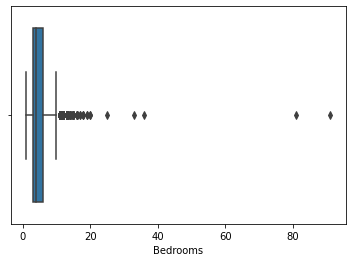

```python
sns.boxplot(df['Bedrooms'])
```

```python
df['Bedrooms'].describe()
```

```
count    11369.000000
mean         4.567156
std          2.707195
min          1.000000
25%          3.000000
50%          4.000000
75%          6.000000
max         91.000000
Name: Bedrooms, dtype: float64
```

```python
df = df[df['Bedrooms']  < 7]
```

Now our data is clean and ready for deeper analysis and safe interpretations of refults.

```python
df.describe().transpose()
```

|  | count | mean | std | min | 25% | 50% | 75% | max |
| --- | --- | --- | --- | --- | --- | --- | --- | --- |
| HouseholdId | 9207.0 | 117092.179320 | 3329.203092 | 111000.0 | 114154.5 | 117454.0 | 119923.5 | 122633.0 |
| WaterSource | 9207.0 | 1.852504 | 1.703267 | 1.0 | 1.0 | 1.0 | 2.0 | 11.0 |
| Toilet | 9207.0 | 2.303465 | 0.563010 | 1.0 | 2.0 | 2.0 | 3.0 | 5.0 |
| ConnectedToGrid | 9207.0 | 1.000000 | 0.000000 | 1.0 | 1.0 | 1.0 | 1.0 | 1.0 |
| CookingFuel | 9207.0 | 3.720647 | 0.982660 | 1.0 | 4.0 | 4.0 | 4.0 | 5.0 |
| WallMaterial | 9207.0 | 1.376018 | 0.929997 | 1.0 | 1.0 | 1.0 | 1.0 | 7.0 |
| FloorMaterial | 9207.0 | 3.189421 | 2.457849 | 1.0 | 2.0 | 2.0 | 2.0 | 13.0 |
| Bedrooms | 9207.0 | 3.610079 | 1.391143 | 1.0 | 3.0 | 4.0 | 5.0 | 6.0 |
| Crime | 9207.0 | 1.055393 | 0.770671 | 1.0 | 1.0 | 1.0 | 1.0 | 20.0 |
| FinancialStatus | 9207.0 | 3.014446 | 0.426307 | 1.0 | 3.0 | 3.0 | 3.0 | 5.0 |
| CutMeals | 9207.0 | 1.000000 | 0.000000 | 1.0 | 1.0 | 1.0 | 1.0 | 1.0 |
| CutMealsFrequency | 9207.0 | 1.025307 | 0.209772 | 1.0 | 1.0 | 1.0 | 1.0 | 3.0 |
| CountOfZeros | 9207.0 | 2.952428 | 1.102264 | 1.0 | 2.0 | 2.0 | 4.0 | 6.0 |

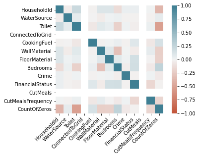

```python
corr = df.corr()
ax = sns.heatmap(
    corr,
    vmin=-1, vmax=1, center=0,
    cmap=sns.diverging_palette(20, 220, n=200),
    square=True
)
ax.set_xticklabels(
    ax.get_xticklabels(),
    rotation=45,
    horizontalalignment='right'
);
```

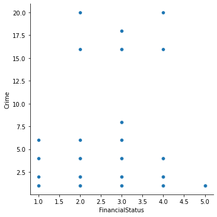

```python
sns.relplot(x="FinancialStatus", y="Crime", data=df, kind="scatter");
```

Variable(s): Crime Options:

0 - Missing/Refused 1 - None 2 - Theft 4 - Assault 6 - Theft & Assault 8 - Murder 10 - Theft & Murder 12 - Assault & Murder 14 - Theft, Assault & Murder 16 - Other crime 18 - Theft & Other crime 20 - Assault & Other crime 22 - Theft, Assault & Other crime 24 - Murder & Other crime 26 - Theft, Murder & Other crime 28 - Assault, Murder & Other crime 30 - Theft, Assault, Murder & Other crime

- The types of crime experienced by these households seem to be associative with the household's financial status.
- Since majority of these households are just getting by (See plot of financial status below), then we suggest the government roll out awareness compaigns as well as community police forums that target crimes associated with groups that are just getting by like Theft, Murder and Assault.

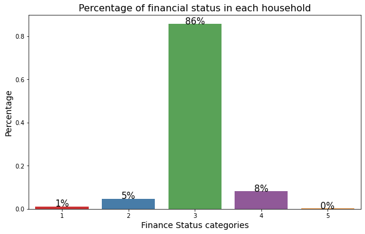

```python
#Ploting barplot for target
plt.figure(figsize=(10,6))
g = sns.barplot(df['FinancialStatus'], df['FinancialStatus'], palette='Set1', estimator=lambda x: len(x) / len(df) )

#Anotating the graph
for p in g.patches:
        width, height = p.get_width(), p.get_height()
        x, y = p.get_xy()
        g.text(x+width/2,
               y+height,
               '{:.0%}'.format(height),
               horizontalalignment='center',fontsize=15)

#Setting the labels
plt.xlabel('Finance Status categories', fontsize=14)
plt.ylabel('Percentage', fontsize=14)
plt.title('Percentage of financial status in each household', fontsize=16)
```

Variable(s): FinancialStatus Options:

0 - Missing/Refused 1 - Extremely Poor 2 - Poor 3 - Just getting by 4 - Comfortable 5 - Very Comfortable

We note that the majority of the households are just getting by financially, we do however; have some households who are comfortable and some who are still poor. The proportion of those who are poor and very poor are too small that it will definitely be cheap to provide extra services for these marginalized but it can be hard to locate them all as they might be scattered amongst the getting by households.

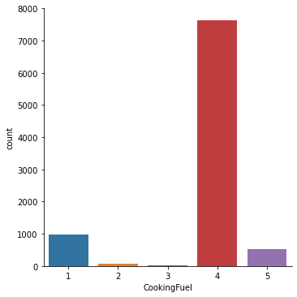

```python
sns.catplot(data=df,x='CookingFuel',kind='count')
```

Variable(s): CookingFuel Options:

0 - Missing/Refused 1 - Wood 2 - Gas (LPG) 3 - Coal 4 - Electricity 5 - Paraffin

We note that majority of households use electricity for cooking; This means these households can benefit a lot from government's subsidy for electricity as it seems to be their main day to day cooking fuel.

However there are some households who still use wood and paraffin; these might either be due to financial status or new stands where electricity is not yet accessible to the households. Government should deploy committes to ensure everyone has access to electricity before subsidising it as suggested

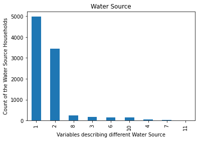

```python
df['WaterSource'].value_counts().plot(kind='bar')
plt.title("Water Source")
plt.xlabel('Variables describing different Water Source')
plt.ylabel('Count of the Water Source Households')
```

# Investigating Toilets

Line of thought: The government usually develop polices to provide toilets to underdeveloped areas for the purposes of ensuring heigen and sanitation for all. It is important to know which toilet systems will most likely be appreciated by each community before rolling out such. so the following are of interest to us:-

[output not shown]

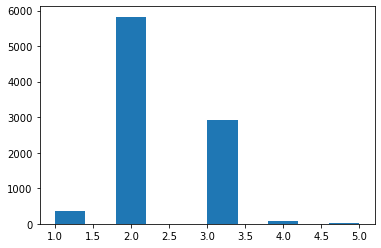

```python
plt.hist(df['Toilet'])
```

Observation:

## Variable(s): Toilet

- 0 - Missing/Refused
- 1 - Flush
- 2 - Ventilated Improved Pit
- 3 - Other Pit Latrine
- 4 - Bucket
- 5 - Chemical
- After strict cleaning of the data we observe that actually Ventilated Improved Pit dominates all other categories, but still with just less than 500 toilets using flushing system.
- We also note that a significant proportion of households still use Other Pit Latrine.
- This suggests the data to be from an area that is still underdeveloped, as it can be seen that less chemical is used